# Multiple Linear Regression

```r
library(here)
# tibbles
library(tidyverse)
# to estimate adjusted p
library(multcomp)
library(emmeans)
```

# The HERS database

The **Heart and Estrogen/progestin Replacement Study (HERS)** is a randomized, double-blind, placebo-controlled trial designed to test the efficacy and safety of estrogen plus progestin therapy for prevention of recurrent **coronary heart disease (CHD)** events in women. The participants are postmenopausal women with a uterus and with CHD as evidenced by prior myocardial infarction, coronary artery bypass graft surgery, percutaneous transluminal coronary angioplasty, or other mechanical revascularization or at least 50% occlusion of a major coronary artery. Between February 1993 and September 1994, 20 HERS centers recruited and randomized 2763 women. The main measured variables in the HERS database, among women with established heart disease, include age, diabetes, smoking status, alcohol consumption (drinkany), exercise, weight, BMI, HDL, and LDL levels, as well as race/ethnicity (nonwhite).

In the HERS database, when 10 is added as a suffix to a variable name, it signifies that the variable represents data measured or recorded at Year 10 of the study, or the 10-year follow-up visit.

The “10” suffix designates that the variable is a repeated measure collected specifically at the decade mark in longitudinal follow-up.3. For example, “weight10” is body weight measured at the 10-year follow-up, as opposed to “weight” measured at baseline. And the “1” suffix designates measurements taken at the 1-year follow-up period within the longitudinal study framework.

```r
# Loading data
hers <- read_csv("~/Dropbox/GitHub/Regression/DataRegressBook/Chap3/hersdata.csv", show_col_types = FALSE)

names(hers)
```

```
##  [1] "HT"       "age"      "raceth"   "nonwhite" "smoking"  "drinkany"
##  [7] "exercise" "physact"  "globrat"  "poorfair" "medcond"  "htnmeds"
## [13] "statins"  "diabetes" "dmpills"  "insulin"  "weight"   "BMI"
## [19] "waist"    "WHR"      "glucose"  "weight1"  "BMI1"     "waist1"
## [25] "WHR1"     "glucose1" "tchol"    "LDL"      "HDL"      "TG"
## [31] "tchol1"   "LDL1"     "HDL1"     "TG1"      "SBP"      "DBP"
## [37] "age10"
```

```r
# hers data structure
hers_nodi <- filter(hers, diabetes == "no")
names(hers_nodi)
```

```
##  [1] "HT"       "age"      "raceth"   "nonwhite" "smoking"  "drinkany"
##  [7] "exercise" "physact"  "globrat"  "poorfair" "medcond"  "htnmeds"
## [13] "statins"  "diabetes" "dmpills"  "insulin"  "weight"   "BMI"
## [19] "waist"    "WHR"      "glucose"  "weight1"  "BMI1"     "waist1"
## [25] "WHR1"     "glucose1" "tchol"    "LDL"      "HDL"      "TG"
## [31] "tchol1"   "LDL1"     "HDL1"     "TG1"      "SBP"      "DBP"
## [37] "age10"
```

# The multiple regression model (4.2)

In the multiple regression model the expected value $E[y \mid x]$ (expected value of the response function y given the vector x) is
$$E[y \mid x] = \beta_0 + \beta_1 x_1 +
\beta_2 x_2 + \beta_3 x_3 + \cdots + \beta_p x_p$$

where $x$ represents the collection of $p$ predictors $x_1, x_2, \ldots x_p$ in the model, and the $\beta$ are the corresponding regression coefficients.

```r
# Chap 4 4.2 Multiple linear predictor model and to obtain the table 4.2 with multiple linear model

hers_nodi_Fit2 <- lm(glucose ~ exercise + age + drinkany + BMI,
                     data = hers_nodi)

summary(hers_nodi_Fit2)
```

```
##
## Call:
## lm(formula = glucose ~ exercise + age + drinkany + BMI, data = hers_nodi)
##
## Residuals:
##     Min      1Q  Median      3Q     Max
## -47.560  -6.400  -0.886   5.496  32.060
##
## Coefficients:
##             Estimate Std. Error t value Pr(>|t|)
## (Intercept) 78.96239    2.59284  30.454   <2e-16 ***
## exerciseyes -0.95044    0.42873  -2.217   0.0267 *
## age          0.06355    0.03139   2.024   0.0431 *
## drinkanyyes  0.68026    0.42196   1.612   0.1071
## BMI          0.48924    0.04155  11.774   <2e-16 ***
## ---
## Signif. codes:  0 '***' 0.001 '**' 0.01 '*' 0.05 '.' 0.1 ' ' 1
##
## Residual standard error: 9.389 on 2023 degrees of freedom
##   (4 observations deleted due to missingness)
## Multiple R-squared:  0.07197,    Adjusted R-squared:  0.07013
## F-statistic: 39.22 on 4 and 2023 DF,  p-value: < 2.2e-16
```

```r
confint(hers_nodi_Fit2)
```

```
##                    2.5 %     97.5 %
## (Intercept) 73.877471178 84.0473167
## exerciseyes -1.791239353 -0.1096426
## age          0.001987207  0.1251118
## drinkanyyes -0.147251352  1.5077796
## BMI          0.407751156  0.5707328
```

## Interpretation of Adjusted Regression Coefficients

The coefficient $\beta_j, j=1, \ldots ,p$ gives the change in $E[y \mid x]$ for an increase of one unit in predictor $x_j$ , holding other factors in the model constant; each of the estimates is adjusted for the effects of all the other predictors. As in the simple linear model, the intercept $\beta_0$ gives the value of $E[y \mid x]$ when all the predictors are equal to zero.

## Generalization of R-squared and r

The coefficient of determination $R^2$ is the proportion of the total variability of the outcome that can be accounted for by the predictors. And the multiple correlation coefficient $r = \sqrt{R^2}$ represents the correlation between the outcome $y$ and the fitted values $\hat{y}$.

# Categorical Predictors

Predictors in both simple and multiple predictor regression models can be binary, categorical, or discrete numeric, as well as continuous numeric.

## Binary Predictors

Binary predictors, a group with a characteristic and other group with out the characteristic, can be coded with a dummy variable, an indicator or dummy variable that can take value “1” for the group with the characteristic and “0” for the group without the characteristic. With this coding, the regression coefficient corresponding to this variable has a straightforward interpretation as the increase or decrease in average outcome levels in the group with the characteristic, with respect to the reference group. With this coding for binary variables `1 = yes` and `0 = no` $\beta_0$ is the average of the baseline variable and $\beta_0 + \beta_1$ is related to the value for the “yes” condition (“yes” + average).

## Multilevel Categorical Predictors (4.3)

The 2,763 women in the HERS cohort also responded to a question about how physically active they considered themselves compared to other women their age. The five-level response variable `physact` ranged from *much less active* to *much more active*, and was coded in order from 1 to 5. This is an example of an ordinal variable. Multilevel categorical variables can also be nominal, in the sense that there is no intrinsic ordering in the categories. Examples include ethnicity, marital status, occupation, and geographic region. With nominal variables, it is even clearer that the numeric codes often used to represent the variable in the database cannot be treated like the values of a numeric variable.  
Categorical variables are easily accommodated in multipredictor linear and other regression models, using indicator or dummy variables. As with binary variables, where two categories are represented in the model by a single indicator variable, categorical variables with $K \leq 2$ levels are represented by $K - 1$ indicators, one for each of level of the variable except a baseline or reference level.

```r
# Chap 4.3 Categorical predictors we are using the HERS data
# Multilevel categorical predictors using the linear model for women without diabetes
# IMPORTANT compare with table 4.4 Regression of physical activity on glucose

hers_nodi <- mutate(hers_nodi,
                    physact = factor(physact, levels=c("much less active",
                                                       "somewhat less active",
                                                       "about as active",
                                                       "somewhat more active",
                                                       "much more active")))

levels(hers_nodi$physact)
```

```
## [1] "much less active"     "somewhat less active" "about as active"
## [4] "somewhat more active" "much more active"
```

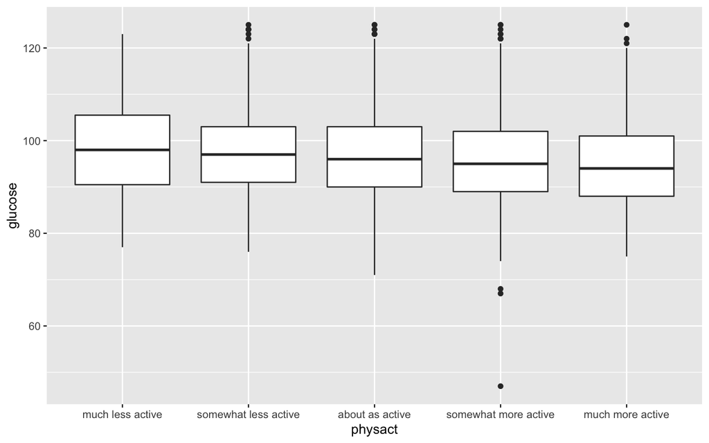

```r
ggplot(data = hers_nodi, mapping = aes(x = physact, y = glucose)) +
  geom_boxplot(na.rm = TRUE)
```

```r
glucose_fit_act <- lm(glucose ~ physact, data = hers_nodi)
#
anova(glucose_fit_act)
```

```
## Analysis of Variance Table
##
## Response: glucose
##             Df Sum Sq Mean Sq F value   Pr(>F)
## physact      4   1673  418.27   4.431 0.001441 **
## Residuals 2027 191345   94.40
## ---
## Signif. codes:  0 '***' 0.001 '**' 0.01 '*' 0.05 '.' 0.1 ' ' 1
```

```r
summary(glucose_fit_act)
```

```
##
## Call:
## lm(formula = glucose ~ physact, data = hers_nodi)
##
## Residuals:
##     Min      1Q  Median      3Q     Max
## -48.987  -6.987  -0.987   5.806  29.857
##
## Coefficients:
##                             Estimate Std. Error t value Pr(>|t|)
## (Intercept)                  98.4206     0.9393 104.784   <2e-16 ***
## physactsomewhat less active  -0.8584     1.0842  -0.792   0.4286
## physactabout as active       -1.2262     1.0111  -1.213   0.2254
## physactsomewhat more active  -2.4339     1.0108  -2.408   0.0161 *
## physactmuch more active      -3.2777     1.1211  -2.924   0.0035 **
## ---
## Signif. codes:  0 '***' 0.001 '**' 0.01 '*' 0.05 '.' 0.1 ' ' 1
##
## Residual standard error: 9.716 on 2027 degrees of freedom
## Multiple R-squared:  0.008668,   Adjusted R-squared:  0.006712
## F-statistic: 4.431 on 4 and 2027 DF,  p-value: 0.001441
```

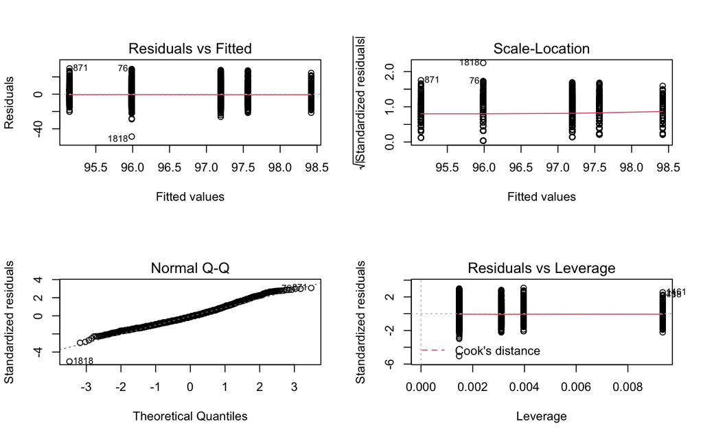

```r
layout(matrix(1:4, nrow = 2))
plot(glucose_fit_act)
```

```r
# To compute the estimates marginal means for specified factors or factor
# combinations in a linear model

glucose_emmeans <- emmeans(glucose_fit_act, "physact")

summary(glucose_emmeans)
```

```
##  physact              emmean    SE   df lower.CL upper.CL
##  much less active       98.4 0.939 2027     96.6    100.3
##  somewhat less active   97.6 0.541 2027     96.5     98.6
##  about as active        97.2 0.374 2027     96.5     97.9
##  somewhat more active   96.0 0.373 2027     95.3     96.7
##  much more active       95.1 0.612 2027     93.9     96.3
##
## Confidence level used: 0.95
```

$$\begin{eqnarray*}
\tt E[glucose \mid x] & = & \tt \beta_0 + \beta_2
SomewhatLessActive + \beta_3 AboutAsActive \\
& & \mbox{} \tt + \beta_4 SomewhatMoreActive
+ \beta_5 MuchMoreActive
\end{eqnarray*}$$

Without other predictors, or covariates, the model is equivalent to a one-way ANOVA. The parameters of the model can be manipulated to give the estimated mean in any group, or to give the estimated differences between any two groups. Estimated differences are the contrasts.

## Multiple Pairwise Comparisons Between Categories

It is frequently of interest to examine multiple pairwise differences between levels of a categorical predictor, especially when the overall F -test is statistically significant, and in some cases even when it is not.  
For this case, various methods are available for controlling the family wise error rate (FER) for the wider set of comparisons being made. These methods differ in the trade-off made between power and the breadth of the circumstances under which the type-I error rate is protected. One of the most straightforward is Fisher’s least significant difference (LSD) procedure, in which the pairwise comparisons are carried out using t -tests at the nominal type-I error rate, but only if the overall F-test is statistically significant.  
More conservative procedures that protect the FER (FWE) under partial null hypotheses include setting the level of the pairwise tests required to declare statistical significance equal to $\alpha/k$ (Bonferroni) or$1-(1-\alpha)^{1/k}$ (Sidak), where $\alpha$ is the desired FER and $k$ is the number of preplanned comparisons to be made. The Sidak correction is slightly more liberal for small values of $k$, but otherwise equivalent.

```r
# Contrasts
# contrasts using the adjusted parameters for a categorical variable with several categories
# or multiple ordinals
# R call categorical variables factors and their categories levels so we have factors with different
# levels in these cases we can estimate contrasts of the adjusted parameters.

Contrast_Table4.6 <- list(gluc_b0 = c(1, 0, 0, 0, 0),
                         gluc_b2 = c(-1, 1, 0, 0, 0),
                         gluc_b3 = c(-1, 0, 1, 0, 0),
                         gluc_b4 = c(-1, 0, 0, 1, 0),
                         gluc_b5 = c(-1, 0, 0, 0, 1))
# For the Bonferroni correction adjust "bonferroni" this is talbe 4.6
contrast(glucose_emmeans, Contrast_Table4.6, adjust="sidak")
```

```
##  contrast estimate    SE   df t.ratio p.value
##  gluc_b0    98.421 0.939 2027 104.784  <.0001
##  gluc_b2    -0.858 1.084 2027  -0.792  0.9391
##  gluc_b3    -1.226 1.011 2027  -1.213  0.7211
##  gluc_b4    -2.434 1.011 2027  -2.408  0.0781
##  gluc_b5    -3.278 1.121 2027  -2.924  0.0174
##
## P value adjustment: sidak method for 5 tests
```

```r
contrast(glucose_emmeans, Contrast_Table4.6, adjust="bonferroni")
```

```
##  contrast estimate    SE   df t.ratio p.value
##  gluc_b0    98.421 0.939 2027 104.784  <.0001
##  gluc_b2    -0.858 1.084 2027  -0.792  1.0000
##  gluc_b3    -1.226 1.011 2027  -1.213  1.0000
##  gluc_b4    -2.434 1.011 2027  -2.408  0.0807
##  gluc_b5    -3.278 1.121 2027  -2.924  0.0175
##
## P value adjustment: bonferroni method for 5 tests
```

## Testing for Trend Across Categories

The coefficient estimates for the categories of physact from last section, decrease in order, suggesting that mean glucose levels are characterized by a linear trend across the levels of `physact`. Tests for linear trend are best performed using a contrast in the coefficients corresponding to the vari`ous levels of the categorical predictor. Definition: A contrast is a weighted sum of the regression coefficients of the form $a_1\beta_1 + a_2\beta_2 + \cdots + a_p\beta_p$ in which the weights, or contrast coefficients, sum to zero: that is, $a_1 + a_2 + \cdots + a_p = 0$

```r
#
Contrasts_glu <- list(MAvsLA         = c(-1, -1, 0,  1,  1),
                     MAvsLAforMuch   = c(-1,  0, 0,  0,  1),
                     MAvsLAforSome   = c( 0, -1, 0,  1,  0),
                     MLAvsC          = c(-1,  0, 1,  0,  0),
                     SLAvsC          = c( 0, -1, 1,  0,  0),
                     SMAvsC          = c( 0,  0,-1,  1,  0),
                     MMAvsC          = c( 0,  0,-1,  0,  1),
                     LinTrend_phys   = c(-2, -1, 0,  1,  2))

# compare the results with emmeans adjusted with Sidak, FWE.
contrast(glucose_emmeans, Contrasts_glu, adjust="bonferroni")
```

```
##  contrast      estimate    SE   df t.ratio p.value
##  MAvsLA          -4.853 1.300 2027  -3.734  0.0016
##  MAvsLAforMuch   -3.278 1.121 2027  -2.924  0.0280
##  MAvsLAforSome   -1.575 0.658 2027  -2.395  0.1336
##  MLAvsC          -1.226 1.011 2027  -1.213  1.0000
##  SLAvsC          -0.368 0.658 2027  -0.559  1.0000
##  SMAvsC          -1.208 0.529 2027  -2.284  0.1796
##  MMAvsC          -2.052 0.717 2027  -2.860  0.0343
##  LinTrend_phys   -8.131 2.337 2027  -3.480  0.0041
##
## P value adjustment: bonferroni method for 8 tests
```

```r
contrast(glucose_emmeans, Contrasts_glu, adjust="sidak")
```

```
##  contrast      estimate    SE   df t.ratio p.value
##  MAvsLA          -4.853 1.300 2027  -3.734  0.0015
##  MAvsLAforMuch   -3.278 1.121 2027  -2.924  0.0276
##  MAvsLAforSome   -1.575 0.658 2027  -2.395  0.1260
##  MLAvsC          -1.226 1.011 2027  -1.213  0.8703
##  SLAvsC          -0.368 0.658 2027  -0.559  0.9990
##  SMAvsC          -1.208 0.529 2027  -2.284  0.1661
##  MMAvsC          -2.052 0.717 2027  -2.860  0.0338
##  LinTrend_phys   -8.131 2.337 2027  -3.480  0.0041
##
## P value adjustment: sidak method for 8 tests
```

```r
# With adjust="none", results will be the same as the aov method.

# Same contrasts with multicomp library
# for other more general examples
# Using the multcomp library

ContrastGlucExa1 <- ("
Contrast.Name     MLA SLA AAA SMA MMA
 MAvsLA           -1  -1   0   1   1
 MAvsLAforMuch    -1   0   0   0   1
 MAvsLAforSome     0  -1   0   1   0
 MLAvsC           -1   0   1   0   0
 SLAvsC            0  -1   1   0   0
 SMAvsC            0   0  -1   1   0
 MMAvsC            0   0  -1   0   1
 LinearTrending   -2  -1   0   1   2
")

ContrastGlucExa1_Matriz = as.matrix(read.table(textConnection(ContrastGlucExa1),
                                               header=TRUE, row.names = 1))
ContrastGlucExa1_Matriz
```

```
##                MLA SLA AAA SMA MMA
## MAvsLA          -1  -1   0   1   1
## MAvsLAforMuch   -1   0   0   0   1
## MAvsLAforSome    0  -1   0   1   0
## MLAvsC          -1   0   1   0   0
## SLAvsC           0  -1   1   0   0
## SMAvsC           0   0  -1   1   0
## MMAvsC           0   0  -1   0   1
## LinearTrending  -2  -1   0   1   2
```

```r
# glucose_fit_act came from lm(glucose ~ physact, data = hers_nodi)
Gluc_GenLinHypoth = glht(glucose_fit_act, linfct = mcp(physact = ContrastGlucExa1_Matriz))

# linear factor linfct
Gluc_GenLinHypoth$linfct
```

```
##                (Intercept) physactsomewhat less active physactabout as active
## MAvsLA                   0                          -1                      0
## MAvsLAforMuch            0                           0                      0
## MAvsLAforSome            0                          -1                      0
## MLAvsC                   0                           0                      1
## SLAvsC                   0                          -1                      1
## SMAvsC                   0                           0                     -1
## MMAvsC                   0                           0                     -1
## LinearTrending           0                          -1                      0
##                physactsomewhat more active physactmuch more active
## MAvsLA                                   1                       1
## MAvsLAforMuch                            0                       1
## MAvsLAforSome                            1                       0
## MLAvsC                                   0                       0
## SLAvsC                                   0                       0
## SMAvsC                                   1                       0
## MMAvsC                                   0                       1
## LinearTrending                           1                       2
## attr(,"type")
## [1] "User-defined"
```

```r
summary(Gluc_GenLinHypoth, test=adjusted("single-step"))
```

```
##
##   Simultaneous Tests for General Linear Hypotheses
##
## Multiple Comparisons of Means: User-defined Contrasts
##
##
## Fit: lm(formula = glucose ~ physact, data = hers_nodi)
##
## Linear Hypotheses:
##                     Estimate Std. Error t value Pr(>|t|)
## MAvsLA == 0          -4.8531     1.2998  -3.734  0.00130 **
## MAvsLAforMuch == 0   -3.2777     1.1211  -2.924  0.02058 *
## MAvsLAforSome == 0   -1.5754     0.6577  -2.395  0.08808 .
## MLAvsC == 0          -1.2262     1.0111  -1.213  0.68329
## SLAvsC == 0          -0.3677     0.6582  -0.559  0.97290
## SMAvsC == 0          -1.2077     0.5287  -2.284  0.11480
## MMAvsC == 0          -2.0515     0.7174  -2.860  0.02500 *
## LinearTrending == 0  -8.1308     2.3366  -3.480  0.00322 **
## ---
## Signif. codes:  0 '***' 0.001 '**' 0.01 '*' 0.05 '.' 0.1 ' ' 1
## (Adjusted p values reported -- single-step method)
```

# Confounding

The model $\tt lm(glucose \sim exercise, data = hers-nodi)$, the unadjusted coefficient for exercise estimates the difference in mean glucose levels between two subgroups of the population of women with heart disease. But this comparison ignores other ways in which those subgroups may differ. In other words, the analysis does not take account of confounding of the association we see. Although the unadjusted coefficient may be useful for describing differences between subgroups, it would be risky to infer any causal connection between exercise and glucose on this basis. In contrast, the adjusted coefficient for exercise in the model:  
$\tt lm(glucose \sim exercise + age + drinkany + BMI, data = hers-nodi)$, takes account of the fact that women who exercise also have lower BMI and are slightly younger and more likely to report alcohol use, all factors which are associated with differences in glucose levels. While this adjusted model is clearly rudimentary, the underlying premise of multipredictor regression analysis of observational data is that with a sufficiently refined model, we can estimate causal effects, free or almost free of confounding. **Confounding is when one predictor $x_i$ (independent variable) can depend in some of the same variables that the response function $Y$.**

## Adjusted vs. unadjusted

Uncontrolled confounding induces bias in unadjusted estimates of the causal effects that are commonly the focus of our attention. This suggests that unadjusted parameter estimates are always biased and adjusted estimates less so.

## Example: BMI and LDL

We turn to a relatively simple example, again using data from the HERS cohort. BMI and LDL cholesterol are both established heart disease risk factors. It is reasonable to hypothesize that higher BMI leads to higher LDL in some causal sense. An unadjusted model for BMI and LDL is obtainde with $\tt lm(LDL \sim BMI, data = hers)$. The unadjusted estimate shows that average LDL increases .42mg/dL per unit increase in BMI.

```r
# when one predictor (independent variable) can depend in
# some of the same variables that the response function
#
# Example of BMI (Body mass index) and LDL (cholesterol)
# using the HERS cohort data Table 4.12

LDL_fit_bmi <- lm(LDL ~ BMI, data = hers)
summary(LDL_fit_bmi)
```

```
##
## Call:
## lm(formula = LDL ~ BMI, data = hers)
##
## Residuals:
##      Min       1Q   Median       3Q      Max
## -107.907  -25.362   -3.487   21.169  244.708
##
## Coefficients:
##             Estimate Std. Error t value Pr(>|t|)
## (Intercept) 133.1913     3.7939  35.107  < 2e-16 ***
## BMI           0.4151     0.1304   3.184  0.00147 **
## ---
## Signif. codes:  0 '***' 0.001 '**' 0.01 '*' 0.05 '.' 0.1 ' ' 1
##
## Residual standard error: 37.75 on 2745 degrees of freedom
##   (16 observations deleted due to missingness)
## Multiple R-squared:  0.00368,    Adjusted R-squared:  0.003317
## F-statistic: 10.14 on 1 and 2745 DF,  p-value: 0.001468
```

However, age, ethnicity (nonwhite), smoking, and alcohol use (drinkany) may confound this unadjusted association. These covariates may either represent determinants of LDL or be proxies for such determinants, and are correlated with but almost surely not caused by BMI, and so may confound the BMI–LDL relationship.

```r
# second half of Table 4.12
# example of LDL modeled with BMI and other factors

LDL_fit_all <- lm(LDL ~ BMI + age + nonwhite + smoking + drinkany,
                  data = hers)
summary(LDL_fit_all)
```

```
##
## Call:
## lm(formula = LDL ~ BMI + age + nonwhite + smoking + drinkany,
##     data = hers)
##
## Residuals:
##      Min       1Q   Median       3Q      Max
## -109.663  -25.285   -3.729   21.210  246.146
##
## Coefficients:
##             Estimate Std. Error t value Pr(>|t|)
## (Intercept) 147.3153     9.2564  15.915  < 2e-16 ***
## BMI           0.3591     0.1341   2.678  0.00746 **
## age          -0.1897     0.1131  -1.678  0.09351 .
## nonwhiteyes   5.2194     2.3237   2.246  0.02477 *
## smokingyes    4.7507     2.2104   2.149  0.03170 *
## drinkanyyes  -2.7224     1.4989  -1.816  0.06944 .
## ---
## Signif. codes:  0 '***' 0.001 '**' 0.01 '*' 0.05 '.' 0.1 ' ' 1
##
## Residual standard error: 37.65 on 2739 degrees of freedom
##   (18 observations deleted due to missingness)
## Multiple R-squared:  0.01077,    Adjusted R-squared:  0.008968
## F-statistic: 5.966 on 5 and 2739 DF,  p-value: 1.7e-05
```

```r
confint(LDL_fit_all)
```

```
##                   2.5 %       97.5 %
## (Intercept) 129.1649620 165.46561698
## BMI           0.0961472   0.62206049
## age          -0.4114427   0.03200946
## nonwhiteyes   0.6631079   9.77576383
## smokingyes    0.4165362   9.08493977
## drinkanyyes  -5.6613516   0.21664447
```

After adjustment for these four demographic and lifestyle factors, the estimated increase in average LDL is 0.36mg/dL per unit increase in BMI, an association that remains highly statistically significant. In addition, average LDL is estimated to be 5.2mg/dL higher among nonwhite women, after adjustment for between-group differences in BMI, age, smoking, and alcohol use. The association of smoking with higher LDL is also statistically significant, and there is some evidence for lower LDL among older women and those who use alcohol. In addition, average LDL is estimated to be 5.2mg/dL higher among nonwhite women, after adjustment for between-group differences in BMI, age, smoking, and alcohol use. The association of smoking with higher LDL is also statistically significant, and there is some evidence for lower LDL among older women and those who use alcohol. In this example, smoking is a negative confounder, because women with higher BMI are less likely to smoke, but both are associated with higher LDL.

# Mediation

If the predictor is cause of one of the covariates which in turn affects the outcome, this will be an instance of *mediation*. For the adjusted model for $\tt LDL \sim BMI + age + nonwhite + smoking + drinkany$ we assumed that age, race/ethnicity, smoking, and alcohol use might confound the effect of BMI, because they affect both BMI and LDL levels, or are proxies for factors that do. However, if the primary predictor is a cause of one of the covariates, which in turn affects the outcome, this would be an instance of mediation.

## Overall and Direct Effects

If the indirect pathway exists, and confounding has been controlled, then the coefficient for the primary predictor before adjustment for the mediator has a causal interpretation as the *overall effect* of the primary predictor on the outcome. The coefficient adjusted for the mediator is interpretable as the so-called *direct effect* of the primary predictor via other pathways that do not involve the mediator. Finally, the *difference* between overall and direct effects of the primary predictor is interpretable as the *indirect effect*.

## Percent Explained

The relative difference between the overall and direct effects is sometimes referred to as the percent explained (PE) and used as an additional summary measure of the indirect effect.

## Example: BMI, exercise, and Glucose

We examined the extent to which the effects of BMI on glucose levels might be mediated through its effects on likelihood of exercise. Although exercise may in some cases affect BMI, in HERS exercise was weakly associated (p = 0.06) with a small increase in BMI over the first year of the study. As a result, we would argue that in this population of older women with established heart disease, BMI mainly affects likelihood of exercise, with very little feedback. Thus, mediation of the effects of BMI by exercise makes sense in terms of a hypothesized causal framework. We recognize that our simple models might not completely control confounding of the relationships among BMI, exercise, and glucose, and could be improved with expert input.

```r
# second half of Table 4.13
# example of LDL modeled with BMI and other factors
Gluc_fit_BMIall <- lm(glucose ~ BMI + age10 + nonwhite +
                      smoking + drinkany + poorfair,
                      data = hers_nodi)

summary(Gluc_fit_BMIall)
```

```
##
## Call:
## lm(formula = glucose ~ BMI + age10 + nonwhite + smoking + drinkany +
##     poorfair, data = hers_nodi)
##
## Residuals:
##     Min      1Q  Median      3Q     Max
## -48.025  -6.367  -0.993   5.536  31.978
##
## Coefficients:
##             Estimate Std. Error t value Pr(>|t|)
## (Intercept) 77.63278    2.68721  28.890   <2e-16 ***
## BMI          0.50256    0.04148  12.115   <2e-16 ***
## age10        0.70940    0.32596   2.176   0.0296 *
## nonwhiteyes  0.88015    0.76108   1.156   0.2476
## smokingyes   0.18126    0.61352   0.295   0.7677
## drinkanyyes  0.71373    0.43050   1.658   0.0975 .
## poorfairyes -0.20525    0.53942  -0.381   0.7036
## ---
## Signif. codes:  0 '***' 0.001 '**' 0.01 '*' 0.05 '.' 0.1 ' ' 1
##
## Residual standard error: 9.407 on 2018 degrees of freedom
##   (7 observations deleted due to missingness)
## Multiple R-squared:  0.07042,    Adjusted R-squared:  0.06766
## F-statistic: 25.48 on 6 and 2018 DF,  p-value: < 2.2e-16
```

```r
confint(Gluc_fit_BMIall)
```

```
##                   2.5 %     97.5 %
## (Intercept) 72.36277899 82.9027874
## BMI          0.42120128  0.5839102
## age10        0.07014944  1.3486433
## nonwhiteyes -0.61243765  2.3727415
## smokingyes  -1.02193064  1.3844492
## drinkanyyes -0.13055024  1.5580088
## poorfairyes -1.26313439  0.8526288
```

```r
# and the second model
Gluc_fit_BMIexer <- lm(glucose ~ BMI + age10 + nonwhite +
                      smoking + drinkany + poorfair + exercise,
                      data = hers_nodi)

summary(Gluc_fit_BMIexer)
```

```
##
## Call:
## lm(formula = glucose ~ BMI + age10 + nonwhite + smoking + drinkany +
##     poorfair + exercise, data = hers_nodi)
##
## Residuals:
##     Min      1Q  Median      3Q     Max
## -47.574  -6.421  -0.879   5.515  32.417
##
## Coefficients:
##             Estimate Std. Error t value Pr(>|t|)
## (Intercept) 78.86342    2.74136  28.768   <2e-16 ***
## BMI          0.48597    0.04211  11.540   <2e-16 ***
## age10        0.66558    0.32624   2.040   0.0415 *
## nonwhiteyes  0.83154    0.76066   1.093   0.2744
## smokingyes  -0.06125    0.62260  -0.098   0.9216
## drinkanyyes  0.69540    0.43017   1.617   0.1061
## poorfairyes -0.33879    0.54225  -0.625   0.5322
## exerciseyes -0.97625    0.44020  -2.218   0.0267 *
## ---
## Signif. codes:  0 '***' 0.001 '**' 0.01 '*' 0.05 '.' 0.1 ' ' 1
##
## Residual standard error: 9.398 on 2017 degrees of freedom
##   (7 observations deleted due to missingness)
## Multiple R-squared:  0.07268,    Adjusted R-squared:  0.06947
## F-statistic: 22.59 on 7 and 2017 DF,  p-value: < 2.2e-16
```

```r
confint(Gluc_fit_BMIexer)
```

```
##                   2.5 %     97.5 %
## (Intercept) 73.48723016 84.2396144
## BMI          0.40337975  0.5685570
## age10        0.02578194  1.3053851
## nonwhiteyes -0.66022672  2.3232986
## smokingyes  -1.28225816  1.1597509
## drinkanyyes -0.14821471  1.5390193
## poorfairyes -1.40222814  0.7246390
## exerciseyes -1.83954846 -0.1129499
```